# 잡케어 추천 알고리즘 경진대회

kuma987

2022년 January 29일

# 사용 패키지

```r
library(dplyr)
library(dlookr)
library(tidyr)
```

```r
library(ggplot2)
library(caret)
library(C50)
library(ROCR)
```

# 데이터 불러오기

[데이터 설명서](https://github.com/kuma987/DACON-Jobcare/blob/main/%EC%84%A4%EB%AA%85%EC%9E%90%EB%A3%8C.md#%EB%8D%B0%EC%9D%B4%ED%84%B0-%EC%84%A4%EB%AA%85%EC%84%9C)

```r
train <- read.csv('/Users/JGH/Desktop/dacon/Jobcare/raw/train.csv')
test <- read.csv('/Users/JGH/Desktop/dacon/Jobcare/raw/test.csv')
d_code <- read.csv('/Users/JGH/Desktop/dacon/Jobcare/raw/속성_D_코드.csv')
h_code <- read.csv('/Users/JGH/Desktop/dacon/Jobcare/raw/속성_H_코드.csv')
l_code <- read.csv('/Users/JGH/Desktop/dacon/Jobcare/raw/속성_L_코드.csv')
colnames(d_code) <- gsub('\\.','_',colnames(d_code))
colnames(h_code) <- gsub('\\.','_',colnames(h_code))
colnames(l_code) <- gsub('\\.','_',colnames(l_code))
head(train)
```

```
##   id d_l_match_yn d_m_match_yn d_s_match_yn h_l_match_yn h_m_match_yn
## 1  0         TRUE         TRUE         TRUE        FALSE        FALSE
## 2  1        FALSE        FALSE        FALSE         TRUE         TRUE
## 3  2        FALSE        FALSE        FALSE         TRUE        FALSE
## 4  3        FALSE        FALSE        FALSE         TRUE        FALSE
## 5  4         TRUE         TRUE         TRUE        FALSE        FALSE
## 6  5        FALSE        FALSE        FALSE         TRUE        FALSE
##   h_s_match_yn person_attribute_a person_attribute_a_1 person_attribute_b
## 1        FALSE                  1                    4                  3
## 2        FALSE                  1                    3                  4
## 3        FALSE                  2                    0                  3
## 4        FALSE                  2                    0                  2
## 5        FALSE                  1                    3                  4
## 6        FALSE                  1                    1                  2
##   person_prefer_c person_prefer_d_1 person_prefer_d_2 person_prefer_d_3
```

[output cut: 48 more lines]

```r
head(test)
```

```
##   id d_l_match_yn d_m_match_yn d_s_match_yn h_l_match_yn h_m_match_yn
## 1  0         TRUE        FALSE        FALSE         TRUE         TRUE
## 2  1        FALSE        FALSE        FALSE         TRUE        FALSE
## 3  2         TRUE        FALSE        FALSE         TRUE         TRUE
## 4  3         TRUE        FALSE        FALSE         TRUE         TRUE
## 5  4         TRUE        FALSE        FALSE         TRUE        FALSE
## 6  5        FALSE        FALSE        FALSE        FALSE        FALSE
##   h_s_match_yn person_attribute_a person_attribute_a_1 person_attribute_b
## 1         TRUE                  1                    1                  2
## 2        FALSE                  2                    0                  2
## 3         TRUE                  2                    3                  2
## 4         TRUE                  1                    2                  2
## 5        FALSE                  1                    6                  4
## 6        FALSE                  1                    2                  3
##   person_prefer_c person_prefer_d_1 person_prefer_d_2 person_prefer_d_3
```

[output cut: 48 more lines]

```r
head(d_code)
```

```
##   속성_D_코드 속성_D_세분류코드 속성_D_소분류코드 속성_D_중분류코드
## 1           4                 4                 3                 2
## 2           5                 5                 3                 2
## 3           7                 7                 6                 2
## 4           8                 8                 6                 2
## 5           9                 8                 6                 2
## 6          10                 8                 6                 2
##   속성_D_대분류코드
## 1                 1
## 2                 1
## 3                 1
## 4                 1
## 5                 1
## 6                 1
```

```r
head(h_code)
```

```
##   속성_H_코드 속성_H_중분류코드 속성_H_대분류코드
## 1           2               315                 1
## 2           4               316                 3
## 3           5               317                 3
## 4           6               318                 3
## 5           7               319                 3
## 6           8               320                 3
```

```r
head(l_code)
```

```
##   속성_L_코드 속성_L_세분류코드 속성_L_소분류코드 속성_L_중분류코드
## 1           1                 1                 1                 1
## 2           2                 2                 2                 1
## 3           3                 3                 2                 1
## 4           4                 3                 2                 1
## 5           5                 5                 2                 1
## 6           6                 5                 2                 1
##   속성_L_대분류코드
## 1              2004
## 2              2004
## 3              2004
## 4              2004
## 5              2004
## 6              2004
```

# 분류모델 선정

의사결정나무 모델 중 하나인 C5.0 모델을 이용  
[C5.0 모델 설정 이유](https://github.com/kuma987/DACON-Jobcare/blob/main/%EC%84%A4%EB%AA%85%EC%9E%90%EB%A3%8C.md#c50-%EB%AA%A8%EB%8D%B8-%EC%84%A0%EC%A0%95-%EC%9D%B4%EC%9C%A0)

# 데이터 전처리

## 결측치

```r
sum(is.na(train))
```

```
## [1] 0
```

```r
sum(is.na(test))
```

```
## [1] 0
```

결측치가 존재하지 않기 때문에 추가적인 전처리 없이 다음 단계로 이동

## 속성 코드 변경

[속성 코드 변경 이유](https://github.com/kuma987/DACON-Jobcare/blob/main/%EC%84%A4%EB%AA%85%EC%9E%90%EB%A3%8C.md#%EC%86%8D%EC%84%B1-%EC%BD%94%EB%93%9C-%EB%B3%80%EA%B2%BD-%EC%9D%B4%EC%9C%A0)

### 속성 코드의 경우

```r
code_list1 <- c('person_prefer_d_1', 'person_prefer_d_2', 'person_prefer_d_3',
               'contents_attribute_d', 'person_prefer_h_1', 'person_prefer_h_2', 'person_prefer_h_3',
               'contents_attribute_h', 'contents_attribute_l')
for (i in code_list1) {
  train[,i] <- factor(train[,i])
}
for (i in code_list1) {
  test[,i] <- factor(test[,i])
}
```

```r
NROW(levels(test$person_prefer_d_1))
```

```
## [1] 955
```

```r
sum(levels(test$person_prefer_d_1) %in% levels(train$person_prefer_d_1))
```

```
## [1] 954
```

person_prefer_d_1의 변수만 살펴봐도, test 데이터에는 955개의 레벨이 존재하지만, 954개의 레벨이 train 데이터에도 존재하고 1개의 데이터는 test 데이터에만 존재  
이에 따라 예측 수행 불가능

```r
NROW(levels(test$person_prefer_d_2)) == sum(levels(test$person_prefer_d_2) %in% levels(train$person_prefer_d_2))
```

```
## [1] FALSE
```

```r
NROW(levels(test$person_prefer_d_3)) == sum(levels(test$person_prefer_d_3) %in% levels(train$person_prefer_d_3))
```

```
## [1] FALSE
```

```r
NROW(levels(test$contents_attribute_d)) == sum(levels(test$contents_attribute_d) %in% levels(train$contents_attribute_d))
```

```
## [1] FALSE
```

```r
NROW(levels(test$person_prefer_h_1)) == sum(levels(test$person_prefer_h_1) %in% levels(train$person_prefer_h_1))
```

```
## [1] TRUE
```

```r
NROW(levels(test$person_prefer_h_2)) == sum(levels(test$person_prefer_h_2) %in% levels(train$person_prefer_h_2))
```

```
## [1] TRUE
```

```r
NROW(levels(test$person_prefer_h_3)) == sum(levels(test$person_prefer_h_3) %in% levels(train$person_prefer_h_3))
```

```
## [1] TRUE
```

```r
NROW(levels(test$contents_attribute_h)) == sum(levels(test$contents_attribute_h) %in% levels(train$contents_attribute_h))
```

```
## [1] TRUE
```

```r
NROW(levels(test$contents_attribute_l)) == sum(levels(test$contents_attribute_l) %in% levels(train$contents_attribute_l))
```

```
## [1] FALSE
```

H 코드가 사용된 변수의 경우 예측 모델 수행에 문제가 없으나, D와 L 코드가 사용된 변수의 경우 변경이 필요

### 속성 세분류 코드의 경우

```r
train <- read.csv('/Users/JGH/Desktop/dacon/Jobcare/raw/train.csv')
test <- read.csv('/Users/JGH/Desktop/dacon/Jobcare/raw/test.csv')
```

```r
train_s <- train
for (i in 1:NROW(train_s)){
  train_s$person_prefer_d_1[i] <- d_code[which(train_s$person_prefer_d_1[i]==d_code$속성_D_코드),'속성_D_세분류코드']
  train_s$person_prefer_d_2[i] <- d_code[which(train_s$person_prefer_d_2[i]==d_code$속성_D_코드),'속성_D_세분류코드']
  train_s$person_prefer_d_3[i] <- d_code[which(train_s$person_prefer_d_3[i]==d_code$속성_D_코드),'속성_D_세분류코드']
  train_s$contents_attribute_d[i] <- d_code[which(train_s$contents_attribute_d[i]==d_code$속성_D_코드),'속성_D_세분류코드']
  train_s$contents_attribute_l[i] <- l_code[which(train_s$contents_attribute_l[i]==l_code$속성_L_코드),'속성_L_세분류코드']
}

test_s <- test
for (i in 1:NROW(test_s)){
  test_s$person_prefer_d_1[i] <- d_code[which(test_s$person_prefer_d_1[i]==d_code$속성_D_코드),'속성_D_세분류코드']
  test_s$person_prefer_d_2[i] <- d_code[which(test_s$person_prefer_d_2[i]==d_code$속성_D_코드),'속성_D_세분류코드']
  test_s$person_prefer_d_3[i] <- d_code[which(test_s$person_prefer_d_3[i]==d_code$속성_D_코드),'속성_D_세분류코드']
  test_s$contents_attribute_d[i] <- d_code[which(test_s$contents_attribute_d[i]==d_code$속성_D_코드),'속성_D_세분류코드']
  test_s$contents_attribute_l[i] <- l_code[which(test_s$contents_attribute_l[i]==l_code$속성_L_코드),'속성_L_세분류코드']
}

code_list2 <- c('person_prefer_d_1', 'person_prefer_d_2', 'person_prefer_d_3',
               'contents_attribute_d', 'contents_attribute_l')
for (i in code_list2) {
  train_s[,i] <- factor(train_s[,i])
}
for (i in code_list2) {
  test_s[,i] <- factor(test_s[,i])
}

NROW(levels(test_s$person_prefer_d_1)) == sum(levels(test_s$person_prefer_d_1) %in% levels(train_s$person_prefer_d_1))
```

```
## [1] TRUE
```

```r
NROW(levels(test_s$person_prefer_d_2)) == sum(levels(test_s$person_prefer_d_2) %in% levels(train_s$person_prefer_d_2))
```

```
## [1] FALSE
```

```r
NROW(levels(test_s$person_prefer_d_3)) == sum(levels(test_s$person_prefer_d_3) %in% levels(train_s$person_prefer_d_3))
```

```
## [1] FALSE
```

```r
NROW(levels(test_s$contents_attribute_d)) == sum(levels(test_s$contents_attribute_d) %in% levels(train_s$contents_attribute_d))
```

```
## [1] FALSE
```

```r
NROW(levels(test_s$contents_attribute_l)) == sum(levels(test_s$contents_attribute_l) %in% levels(train_s$contents_attribute_l))
```

```
## [1] FALSE
```

D와 L 코드가 사용된 변수의 속성 코드를 속성 세분류 코드로 변경하여도 예측 수행 불가능

### 속성 중분류 코드의 경우

```r
train <- read.csv('/Users/JGH/Desktop/dacon/Jobcare/raw/train.csv')
test <- read.csv('/Users/JGH/Desktop/dacon/Jobcare/raw/test.csv')
```

```r
train_m <- train
for (i in 1:NROW(train_m)){
  train_m$person_prefer_d_1[i] <- d_code[which(train_m$person_prefer_d_1[i]==d_code$속성_D_코드),'속성_D_중분류코드']
  train_m$person_prefer_d_2[i] <- d_code[which(train_m$person_prefer_d_2[i]==d_code$속성_D_코드),'속성_D_중분류코드']
  train_m$person_prefer_d_3[i] <- d_code[which(train_m$person_prefer_d_3[i]==d_code$속성_D_코드),'속성_D_중분류코드']
  train_m$contents_attribute_d[i] <- d_code[which(train_m$contents_attribute_d[i]==d_code$속성_D_코드),'속성_D_중분류코드']
  train_m$contents_attribute_l[i] <- l_code[which(train_m$contents_attribute_l[i]==l_code$속성_L_코드),'속성_L_중분류코드']
}

test_m <- test
for (i in 1:NROW(test_m)){
  test_m$person_prefer_d_1[i] <- d_code[which(test_m$person_prefer_d_1[i]==d_code$속성_D_코드),'속성_D_중분류코드']
  test_m$person_prefer_d_2[i] <- d_code[which(test_m$person_prefer_d_2[i]==d_code$속성_D_코드),'속성_D_중분류코드']
  test_m$person_prefer_d_3[i] <- d_code[which(test_m$person_prefer_d_3[i]==d_code$속성_D_코드),'속성_D_중분류코드']
  test_m$contents_attribute_d[i] <- d_code[which(test_m$contents_attribute_d[i]==d_code$속성_D_코드),'속성_D_중분류코드']
  test_m$contents_attribute_l[i] <- l_code[which(test_m$contents_attribute_l[i]==l_code$속성_L_코드),'속성_L_중분류코드']
}

for (i in code_list2) {
  train_m[,i] <- factor(train_m[,i])
}
for (i in code_list2) {
  test_m[,i] <- factor(test_m[,i])
}

NROW(levels(test_m$person_prefer_d_1)) == sum(levels(test_m$person_prefer_d_1) %in% levels(train_m$person_prefer_d_1))
```

```
## [1] TRUE
```

```r
NROW(levels(test_m$person_prefer_d_2)) == sum(levels(test_m$person_prefer_d_2) %in% levels(train_m$person_prefer_d_2))
```

```
## [1] TRUE
```

```r
NROW(levels(test_m$person_prefer_d_3)) == sum(levels(test_m$person_prefer_d_3) %in% levels(train_m$person_prefer_d_3))
```

```
## [1] TRUE
```

```r
NROW(levels(test_m$contents_attribute_d)) == sum(levels(test_m$contents_attribute_d) %in% levels(train_m$contents_attribute_d))
```

```
## [1] TRUE
```

```r
NROW(levels(test_m$contents_attribute_l)) == sum(levels(test_m$contents_attribute_l) %in% levels(train_m$contents_attribute_l))
```

```
## [1] TRUE
```

## 변수 형태 변환

데이터 설명서에 적합하도록 데이터 형태 변환

- 명목형 변수

```r
factor_list1 <- c('person_attribute_a','person_prefer_c','person_prefer_d_1','person_prefer_d_2',
                 'person_prefer_d_3','person_prefer_f','person_prefer_g','person_prefer_h_1',
                 'person_prefer_h_2','person_prefer_h_3','contents_attribute_i','contents_attribute_a',
                 'contents_attribute_j_1','contents_attribute_j','contents_attribute_c','contents_attribute_k',
                 'contents_attribute_l','contents_attribute_d','contents_attribute_m','contents_attribute_h',
                 'target')
for (i in factor_list1) {
  train_m[,i] <- factor(train_m[,i])
}

factor_list2 <- c('person_attribute_a','person_prefer_c','person_prefer_d_1','person_prefer_d_2',
                 'person_prefer_d_3','person_prefer_f','person_prefer_g','person_prefer_h_1',
                 'person_prefer_h_2','person_prefer_h_3','contents_attribute_i','contents_attribute_a',
                 'contents_attribute_j_1','contents_attribute_j','contents_attribute_c','contents_attribute_k',
                 'contents_attribute_l','contents_attribute_d','contents_attribute_m','contents_attribute_h')
for (i in factor_list2) {
  test_m[,i] <- factor(test_m[,i])
}
```

- 순서형 변수

```r
order_list <- c('person_attribute_a_1','person_attribute_b','person_prefer_e','contents_attribute_e')

for (i in order_list) {
  train_m[,i] <- factor(train_m[,i], order=T)
}

for (i in order_list) {
  test_m[,i] <- factor(test_m[,i], order=T)
}
```

- 날짜형 변수

```r
train_m$contents_open_dt <- as.POSIXct(train_m$contents_open_dt, format='%Y.%m.%d %H:%M')
test_m$contents_open_dt <- as.POSIXct(test_m$contents_open_dt, format='%Y.%m.%d %H:%M')
```

- 논리형 변수

```r
# 논리형이지만 분류모델에서 변수로 활용 가능하도록 범주형으로 변환
logic_list <- c('d_l_match_yn','d_m_match_yn','d_s_match_yn','h_l_match_yn','h_m_match_yn','h_s_match_yn')

for (i in logic_list) {
  train_m[,i] <- factor(ifelse(train_m[,i]==TRUE,1,0))
}

for (i in logic_list) {
  test_m[,i] <- factor(ifelse(test_m[,i]==TRUE,1,0))
}
```

```r
str(train_m)
```

```
## 'data.frame':    501951 obs. of  35 variables:
##  $ id                    : int  0 1 2 3 4 5 6 7 8 9 ...
##  $ d_l_match_yn          : Factor w/ 2 levels "0","1": 2 1 1 1 2 1 1 2 2 1 ...
##  $ d_m_match_yn          : Factor w/ 2 levels "0","1": 2 1 1 1 2 1 1 1 2 1 ...
##  $ d_s_match_yn          : Factor w/ 2 levels "0","1": 2 1 1 1 2 1 1 1 1 1 ...
##  $ h_l_match_yn          : Factor w/ 2 levels "0","1": 1 2 2 2 1 2 2 2 2 2 ...
##  $ h_m_match_yn          : Factor w/ 2 levels "0","1": 1 2 1 1 1 1 1 1 1 1 ...
##  $ h_s_match_yn          : Factor w/ 2 levels "0","1": 1 1 1 1 1 1 1 1 1 1 ...
##  $ person_attribute_a    : Factor w/ 2 levels "1","2": 1 1 2 2 1 1 2 1 1 1 ...
##  $ person_attribute_a_1  : Ord.factor w/ 8 levels "0"<"1"<"2"<"3"<..: 5 4 1 1 4 2 1 3 2 6 ...
##  $ person_attribute_b    : Ord.factor w/ 6 levels "0"<"1"<"2"<"3"<..: 4 5 4 3 5 3 4 3 3 3 ...
##  $ person_prefer_c       : Factor w/ 5 levels "1","2","3","4",..: 5 1 5 5 5 5 5 1 5 1 ...
##  $ person_prefer_d_1     : Factor w/ 36 levels "2","56","189",..: 7 2 11 20 7 2 19 8 27 24 ...
##  $ person_prefer_d_2     : Factor w/ 36 levels "2","56","189",..: 8 2 2 20 8 2 2 8 34 20 ...
##  $ person_prefer_d_3     : Factor w/ 36 levels "2","56","189",..: 8 2 11 20 8 2 22 2 26 34 ...
```

[output cut: 21 more lines]

```r
str(test_m)
```

```
## 'data.frame':    46404 obs. of  34 variables:
##  $ id                    : int  0 1 2 3 4 5 6 7 8 9 ...
##  $ d_l_match_yn          : Factor w/ 2 levels "0","1": 2 1 2 2 2 1 1 2 2 1 ...
##  $ d_m_match_yn          : Factor w/ 2 levels "0","1": 1 1 1 1 1 1 1 1 1 1 ...
##  $ d_s_match_yn          : Factor w/ 2 levels "0","1": 1 1 1 1 1 1 1 1 1 1 ...
##  $ h_l_match_yn          : Factor w/ 2 levels "0","1": 2 2 2 2 2 1 2 2 2 1 ...
##  $ h_m_match_yn          : Factor w/ 2 levels "0","1": 2 1 2 2 1 1 1 1 1 1 ...
##  $ h_s_match_yn          : Factor w/ 2 levels "0","1": 2 1 2 2 1 1 1 1 1 1 ...
##  $ person_attribute_a    : Factor w/ 2 levels "1","2": 1 2 2 1 1 1 2 2 2 1 ...
##  $ person_attribute_a_1  : Ord.factor w/ 8 levels "0"<"1"<"2"<"3"<..: 2 1 4 3 7 3 1 1 1 8 ...
##  $ person_attribute_b    : Ord.factor w/ 6 levels "0"<"1"<"2"<"3"<..: 3 3 3 3 5 4 5 5 5 3 ...
##  $ person_prefer_c       : Factor w/ 5 levels "1","2","3","4",..: 1 2 1 5 5 1 5 5 5 5 ...
##  $ person_prefer_d_1     : Factor w/ 35 levels "2","56","189",..: 24 19 14 2 28 2 23 11 9 25 ...
##  $ person_prefer_d_2     : Factor w/ 34 levels "2","56","189",..: 23 27 22 2 27 2 2 2 11 24 ...
##  $ person_prefer_d_3     : Factor w/ 35 levels "2","56","189",..: 33 18 33 2 27 2 22 2 8 23 ...
```

[output cut: 20 more lines]

### 변수 탐색 및 제거

- 수치형 변수

```r
diagnose(select_if(train_m,is.numeric))
```

```
## # A tibble: 3 x 6
##   variables   types   missing_count missing_percent unique_count unique_rate
##   <chr>       <chr>           <int>           <dbl>        <int>       <dbl>
## 1 id          integer             0               0       501951       1
## 2 person_rn   integer             0               0       300177       0.598
## 3 contents_rn integer             0               0       283359       0.565
```

```r
diagnose(select_if(test_m,is.numeric))
```

```
## # A tibble: 3 x 6
##   variables   types   missing_count missing_percent unique_count unique_rate
##   <chr>       <chr>           <int>           <dbl>        <int>       <dbl>
## 1 id          integer             0               0        46404       1
## 2 person_rn   integer             0               0        34534       0.744
## 3 contents_rn integer             0               0        31489       0.679
```

id, person_rn, contents_rn 변수 제거  
[변수 제거 이유](https://github.com/kuma987/DACON-Jobcare/blob/main/%EC%84%A4%EB%AA%85%EC%9E%90%EB%A3%8C.md#%EB%B3%80%EC%88%98-%EC%A0%9C%EA%B1%B0-%EC%9D%B4%EC%9C%A0)

```r
train_m <- train_m[,!names(train_m) %in% c('id','person_rn','contents_rn')]
test_m <- test_m[,!names(test_m) %in% c('id','person_rn','contents_rn')]
```

- 범주형 변수

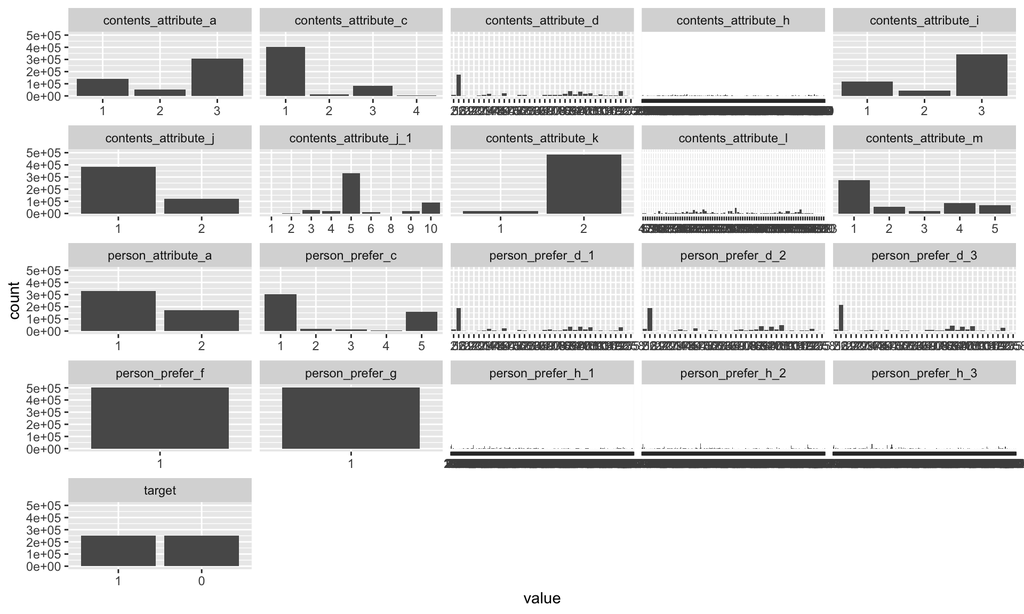

```r
ggplot(pivot_longer(train_m[,factor_list1],everything())) + geom_bar(aes(x=value))+
  facet_wrap(~name, scales='free_x')
```

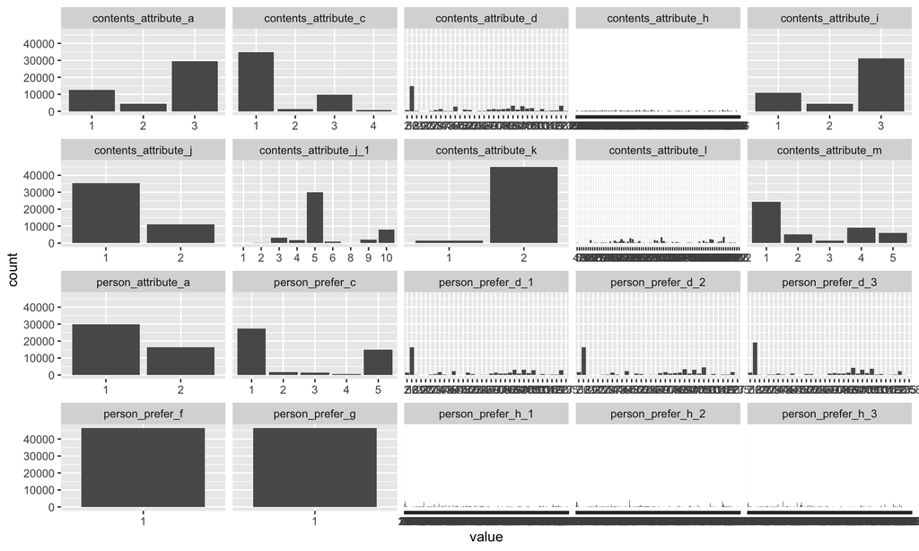

```r
ggplot(pivot_longer(test_m[,factor_list2],everything())) + geom_bar(aes(x=value))+
  facet_wrap(~name, scales='free_x')
```

person_prefer_f와 person_prefer_g

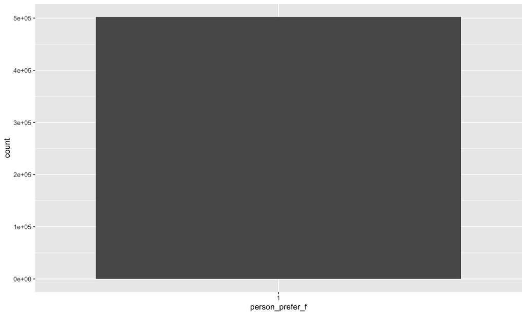

```r
ggplot(train_m) + geom_bar(aes(x=person_prefer_f))
```

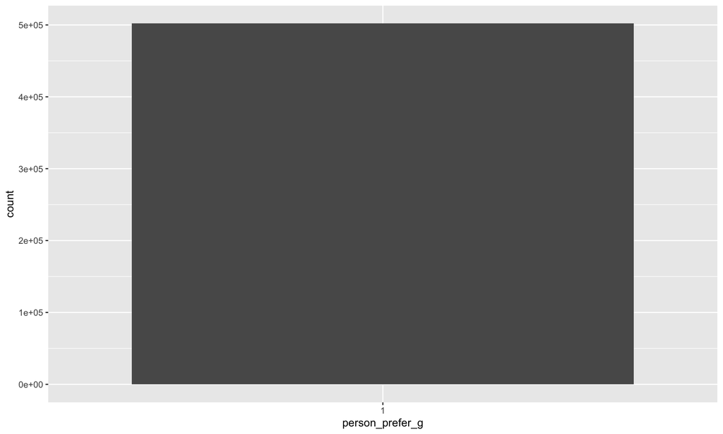

```r
ggplot(train_m) + geom_bar(aes(x=person_prefer_g))
```

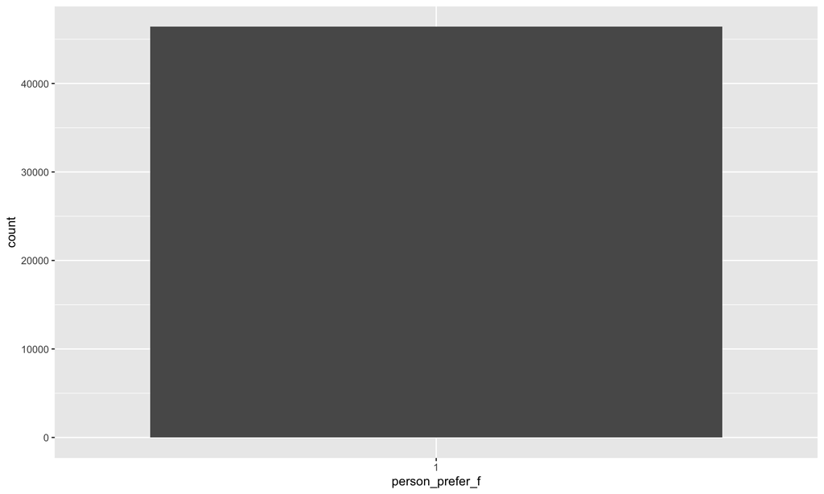

```r
ggplot(test_m) + geom_bar(aes(x=person_prefer_f))
```

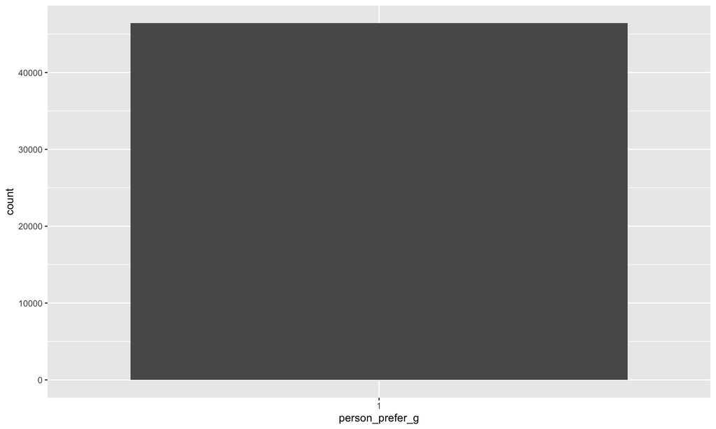

```r
ggplot(test_m) + geom_bar(aes(x=person_prefer_g))
```

person_prefer_f, person_prefer_g 변수 제거  
[변수 제거 이유](https://github.com/kuma987/DACON-Jobcare/blob/main/%EC%84%A4%EB%AA%85%EC%9E%90%EB%A3%8C.md#%EB%B3%80%EC%88%98-%EC%A0%9C%EA%B1%B0-%EC%9D%B4%EC%9C%A0)

```r
train_m <- train_m[,!names(train_m) %in% c('person_prefer_f','person_prefer_g')]
test_m <- test_m[,!names(test_m) %in% c('person_prefer_f','person_prefer_g')]
```

목표 변수의 불균형 정도 확인

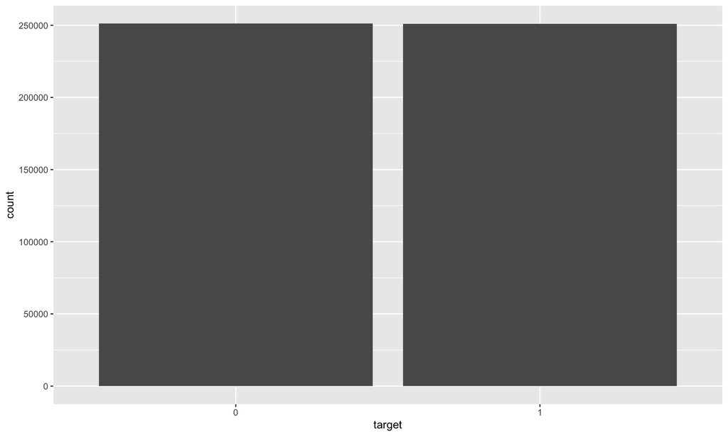

```r
ggplot(train_m) + geom_bar(aes(x=target))
```

불균형이 존재하지 않기 때문에 추가적인 전처리 없이 다음 단계로 이동

- 날짜형 변수

contents_open_dt 변수 제거  
[변수 제거 이유](https://github.com/kuma987/DACON-Jobcare/blob/main/%EC%84%A4%EB%AA%85%EC%9E%90%EB%A3%8C.md#%EB%B3%80%EC%88%98-%EC%A0%9C%EA%B1%B0-%EC%9D%B4%EC%9C%A0)

```r
train_m <- train_m[,!names(train_m) %in% 'contents_open_dt']
test_m <- test_m[,!names(test_m) %in% 'contents_open_dt']
```

# 데이터 분할

기존의 train 데이터를 훈련:검증 = 7:3 비율로 분할 수행

```r
set.seed(1234)
folds <- createFolds(train_m$target, k=10, list=T)
idx_t <- unname(unlist(folds[1:7]))
idx_v <- unname(unlist(folds[8:10]))
train_m_t <- train_m[idx_t,]
train_m_v <- train_m[idx_v,]
```

```r
table(train_m$target)
```

```
##
##      0      1
## 251106 250845
```

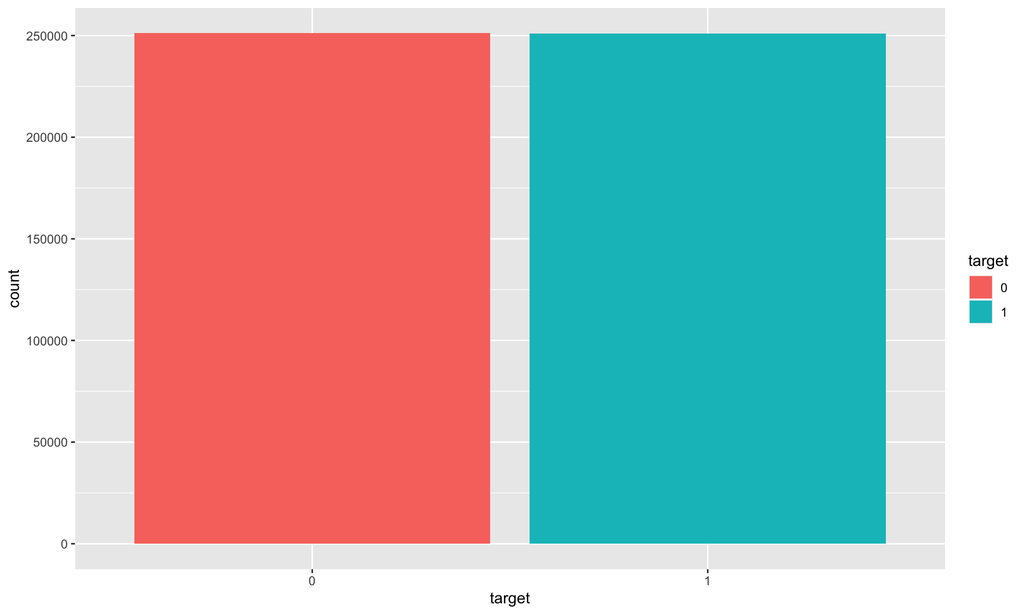

```r
ggplot(train_m) + geom_bar(aes(x=target,fill=target))
```

```r
table(train_m_t$target)
```

```
##
##      0      1
## 175774 175591
```

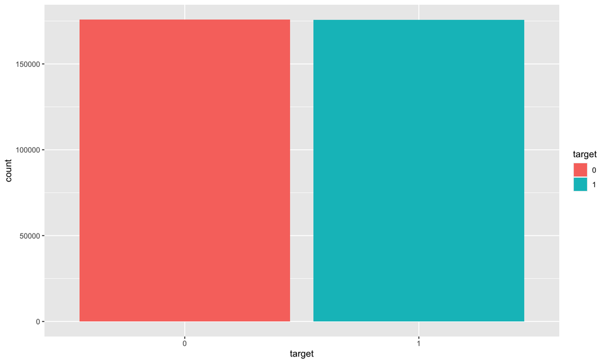

```r
ggplot(train_m_t) + geom_bar(aes(x=target, fill=target))
```

```r
table(train_m_v$target)
```

```
##
##     0     1
## 75332 75254
```

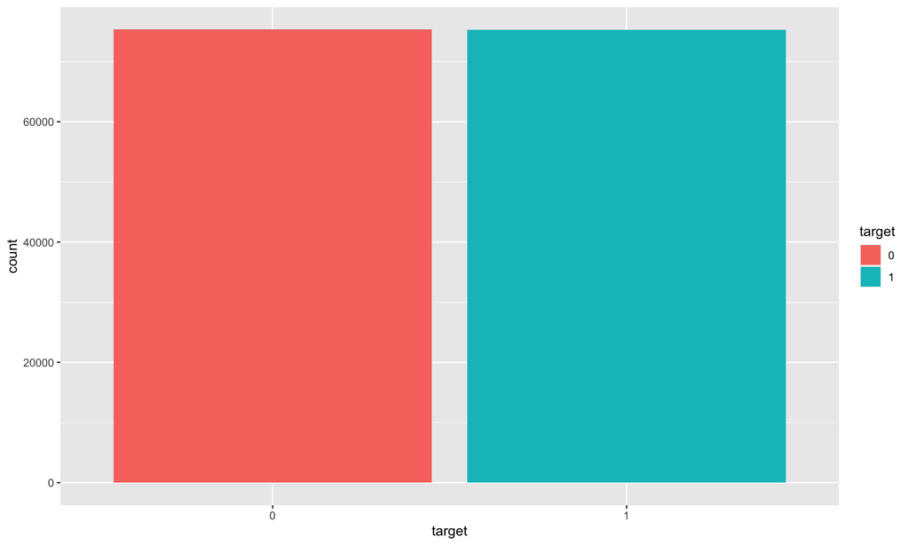

```r
ggplot(train_m_v) + geom_bar(aes(x=target, fill=target))
```

분할 이후에도 기존 목표변수의 비율이 깨지지 않았다는 것을 확인 가능

# 모델링

```r
C5.0_model <- C5.0(train_m_t[,!names(train_m_t) %in% 'target'], train_m_t$target, trials=10)
```

```r
summary(C5.0_model)
```

[output not shown]

[모델 설명](https://github.com/kuma987/DACON-Jobcare/blob/main/%EC%84%A4%EB%AA%85%EC%9E%90%EB%A3%8C.md#%EB%B3%80%EC%88%98-%EC%A0%9C%EA%B1%B0-%EC%9D%B4%EC%9C%A0)

# cutoff 함수 생성

cutoff에 따라 생성된 모델의 정확도, 정밀도, 재현율, F1-Score를 제시해주는 함수 생성  
cutoff는 0부터 1까지 0.01 단위로 제시

```r
cutoff_df <- function(model, valid_data, range) {
  prob <- predict(model, valid_data, type='prob')[,2]
  df <- as.data.frame(matrix(NA, nrow=NROW(range), ncol=5))
  colnames(df) <- c('Cutoff', 'Accuracy','Precision','Recall','F1')

  for (i in 1:NROW(range)){
    pred <- as.factor(ifelse(prob > range[i], 1, 0))
    accuracy <- confusionMatrix(pred, valid_data$target, positive = '1')$overall['Accuracy']
    precision <- posPredValue(pred, valid_data$target, positive = '1')
    recall <- sensitivity(pred, valid_data$target, positive = '1')
    F1_score <- (2*precision*recall)/(precision+recall)
    df[i,] <- c(range[i], accuracy, precision, recall, F1_score)
  }
  df <- df %>% arrange(desc(F1))
  return(df)
}
```

```r
cutoff_range <- seq(0,1,0.01)
model_df <- cutoff_df(C5.0_model,train_m_v, cutoff_range)
model_df[which(model_df$Cutoff==0.5),]
```

```
##    Cutoff Accuracy Precision    Recall        F1
## 51    0.5 0.599737 0.5966676 0.6143328 0.6053714
```

```r
model_df
```

```
##     Cutoff  Accuracy Precision     Recall         F1
## 1     0.19 0.5550051 0.5307044 0.94674037 0.68014625
## 2     0.18 0.5482847 0.5263549 0.95965663 0.67983319
## 3     0.20 0.5603376 0.5343964 0.93389056 0.67979590
## 4     0.21 0.5635716 0.5367195 0.92590427 0.67953344
## 5     0.22 0.5652119 0.5379129 0.92203737 0.67944205
## 6     0.23 0.5658229 0.5383993 0.91975177 0.67920770
## 7     0.17 0.5435698 0.5234675 0.96659314 0.67914029
## 8     0.25 0.5662346 0.5387502 0.91774524 0.67893850
## 9     0.24 0.5659291 0.5385281 0.91838308 0.67893648
## 10    0.26 0.5668123 0.5391870 0.91620379 0.67886259
## 11    0.27 0.5689440 0.5407876 0.91114094 0.67872999
## 12    0.16 0.5415576 0.5222831 0.96848008 0.67860651
## 13    0.14 0.5412455 0.5220987 0.96883887 0.67853886
## 14    0.15 0.5412854 0.5221240 0.96871927 0.67853087
```

[output cut: 87 more lines]

```r
cutoff <- model_df[1,1]
cutoff
```

```
## [1] 0.19
```

정확도는 떨어져도 DACON의 목적이 F1-score인 만큼, 이에 초점을 맞춰서 F1-score가 가장 높은 경우의 cutoff를 채택  
* cutoff가 낮은 의미는 오분류를 하더라도 고객이 콘텐츠를 이용하고자 한다는 사실을 놓치지 않는 것을  
더 중요하게 여기는 예측모델이 생성됨을 의미

# 모델 성능

생성한 검증용 데이터를 이용하여 모델 성능 평가

```r
pred_prob <- predict(C5.0_model, train_m_v, type='prob')[,2]
pred_class <- as.factor(ifelse(pred_prob >= cutoff, 1 ,0))
caret::confusionMatrix(pred_class, train_m_v$target, positive='1')
```

```
## Confusion Matrix and Statistics
##
##           Reference
## Prediction     0     1
##          0 12330  4008
##          1 63002 71246
##
##                Accuracy : 0.555
##                  95% CI : (0.5525, 0.5575)
##     No Information Rate : 0.5003
##     P-Value [Acc > NIR] : < 2.2e-16
##
##                   Kappa : 0.1104
##
##  Mcnemar's Test P-Value : < 2.2e-16
##
##             Sensitivity : 0.9467
##             Specificity : 0.1637
##          Pos Pred Value : 0.5307
##          Neg Pred Value : 0.7547
##              Prevalence : 0.4997
##          Detection Rate : 0.4731
##    Detection Prevalence : 0.8915
##       Balanced Accuracy : 0.5552
##
##        'Positive' Class : 1
##
```

```r
precision <- posPredValue(pred_class, train_m_v$target, positive='1')
recall <- sensitivity(pred_class, train_m_v$target, positive='1')
F1_score <- (2*precision*recall)/(precision+recall)
F1_score
```

```
## [1] 0.6801463
```

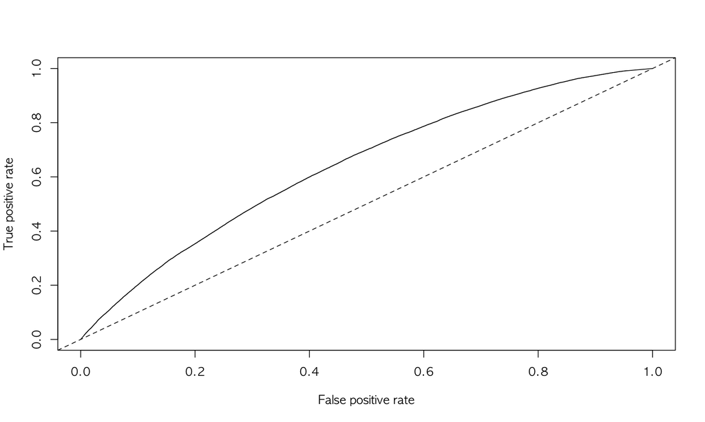

```r
roc_curve <- prediction(pred_prob, train_m_v$target)
plot(performance(roc_curve,'tpr','fpr'))
abline(a=0, b=1,lty=2, col='black')
```

# 결과

```r
test_prob <- predict(C5.0_model, test_m, type='prob')[,2]
target <- as.factor(ifelse(test_prob >= cutoff, 1,0))
result <- cbind(test,target)[,c('id','target')]
head(result)
```

```
##   id target
## 1  0      1
## 2  1      1
## 3  2      1
## 4  3      1
## 5  4      1
## 6  5      1
```

# 결과 생성

```r
# write.csv(result,'/Users/JGH/Desktop/dacon/Jobcare/result/result.csv', row.names=F)
```